# Stepwise Multiple Regressions

Leah Thornton Hampton

2/1/2021

# 1 Set Up

#Variables to put into model

- Dose (counts)
- Dose (mass)
- Dose (volume)
- Size (continuous)
- Size (binned)
- Polymer type
- Shape
- Organism Group (this is being used as a temporary substitute for body size)
- Life Stage
- Level of Biological Organization
- Exposure Duration
- Acute/Chronic (this values are only complete for fish, molluscs, crustaceans and algae)
- Charge (negative/positive - categorical)
- Zeta potential
- Particle Source (commercial, generated in-house, or mmodified commercial particles e.g., milling)

Response Variables * Effect (Y/N) - Binary Data * Effect (Y/N) - Binary Data x Effect Score (binned organism level effects)

#Continous Variable Distributions

There are several continuous variables that we want to feed into our model. Before doing so, we’re going to check the distribution to see if any of them are skewed and need to be transformed.

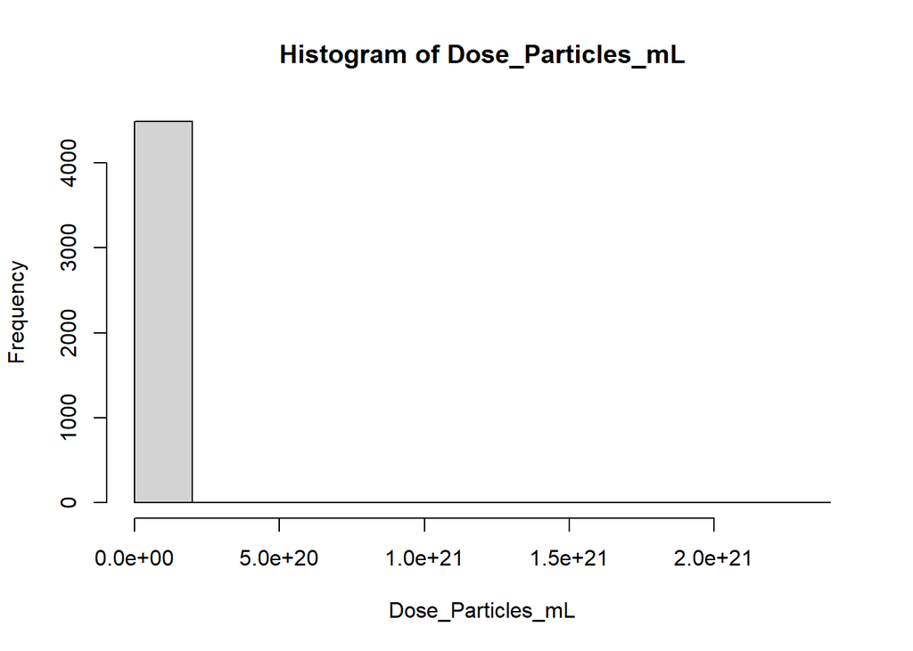

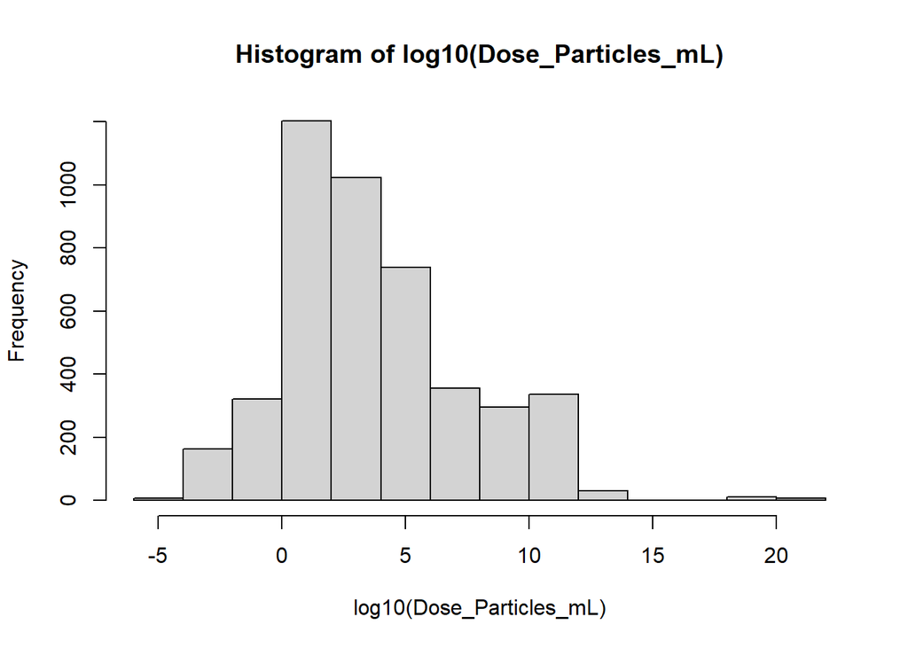

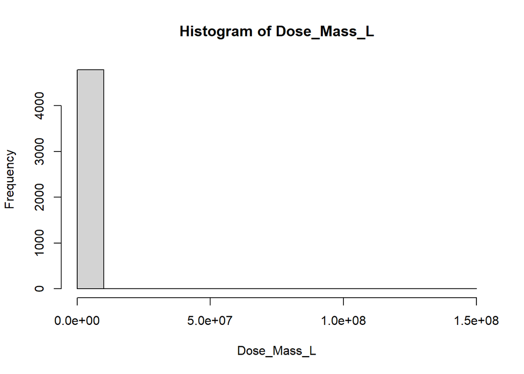

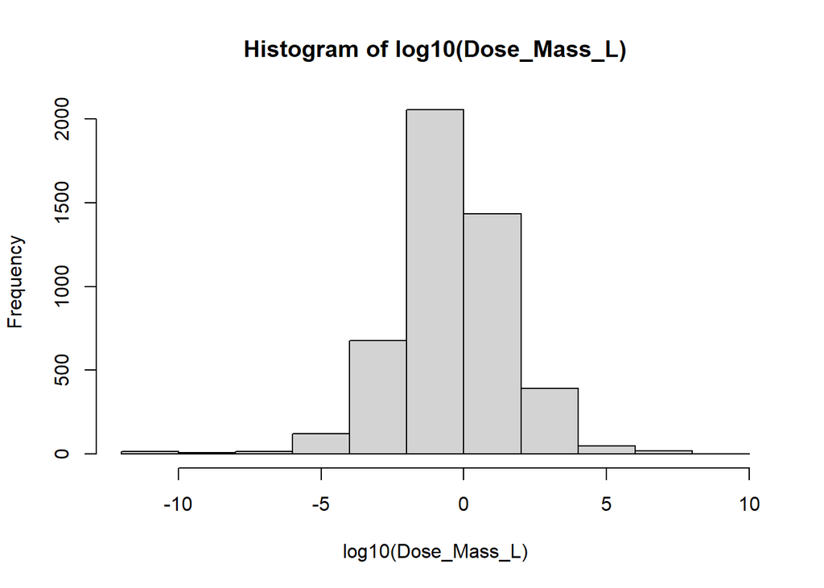

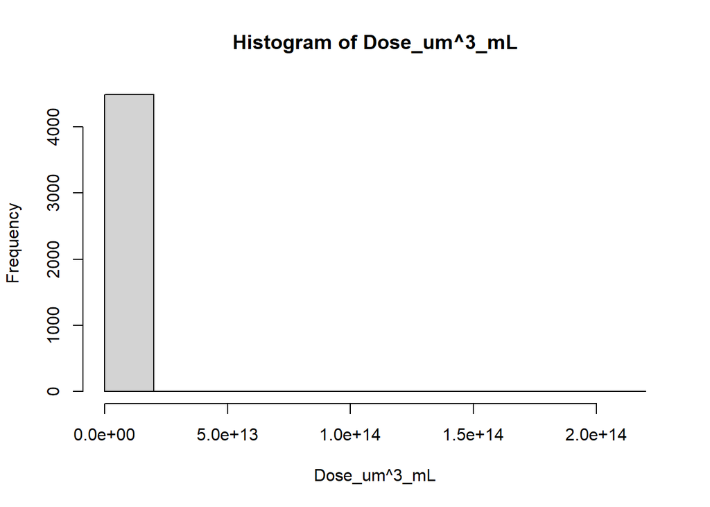

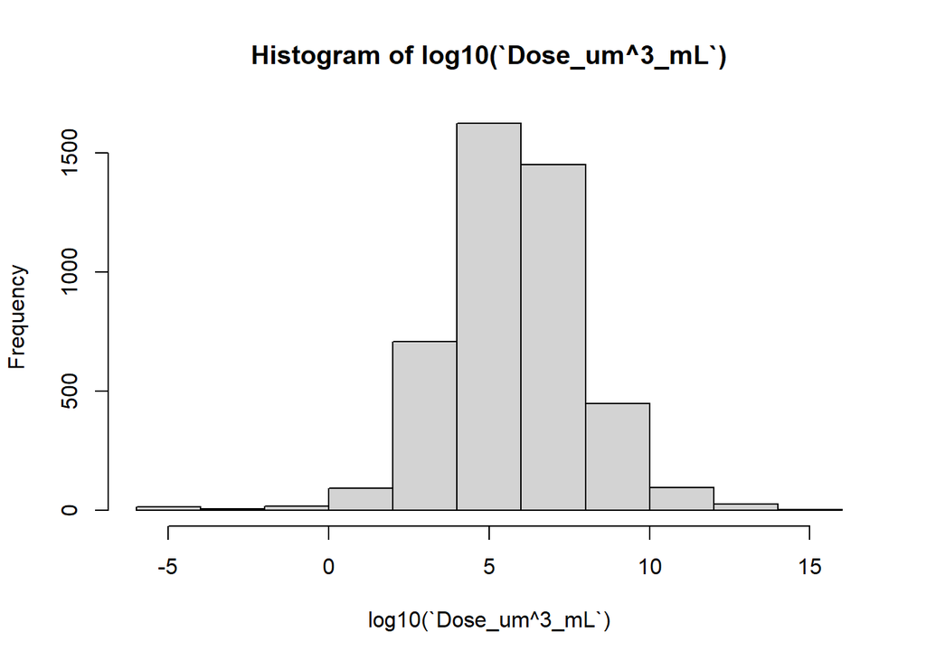

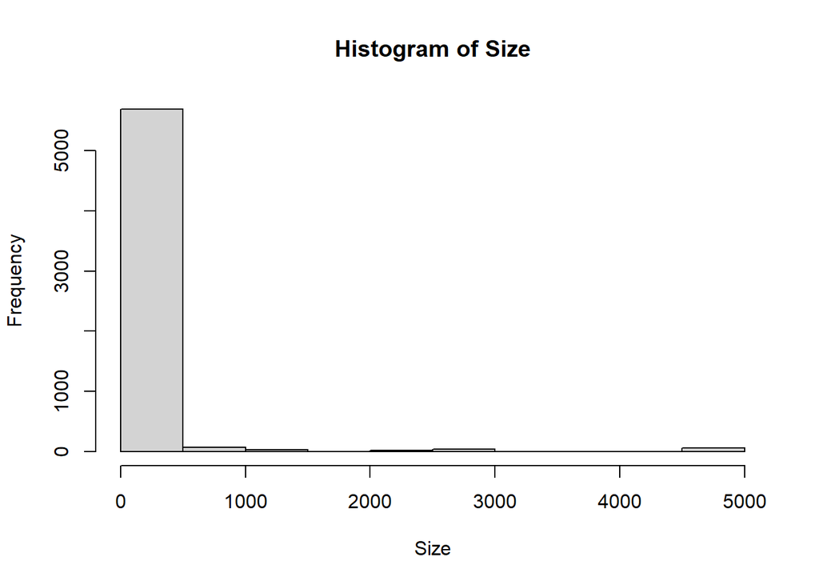